# Modeling summary

Sebastian Schuster

10/2/2020

## Model comparison

**Models**:

- *full*: each expression has parameters for threshold distributions; estimated on all data
- *no near-synonyms estimation*: each expression has parameters for threshold distributions; estimated on all data except near-synonym conditions (e.g., *might-could*)
- *classic semantics*: the sets {might, could, possible} and {probably, likely} each share parameters for threshold distributions; estimated on all data
- *classic semantics, no near-synonyms estimation*: the sets {might, could, possible} and {probably, likely} each share parameters for threshold distributions; estimated on all data except near-synonym conditions (e.g., *might-could*)
- *might=possible*: *might* and *possible* share parameters for threshold distributions; estimated on all data
- *might=possible, no near-synonyms estimation*: *might* and *possible* share parameters for threshold distributions; estimated on all data except near-synonym conditions (e.g., *might-could*)

**Colums:**:

- $R^2$ (all data): $R^2$ between mean model predictions and mean participant ratings for all conditions
- $R^2$ (no near-synonyms): $R^2$ between mean model predictions and mean participant ratings for all conditions except near-synonym conditions
- rel. LogLik: log likelihood of data given the model, relative to best model

| Model | $R^2$ (all data) | $R^2$ (no near-synonyms) | rel. LogLik (all data) | rel. LogLik (no near-synonyms) |
| --- | --- | --- | --- | --- |
| full | **0.941** | 0.945 | **0** | -22 |
| full, no near-synonyms estimation | 0.940 | **0.947** | -28 | **0** |
| classic semantics | 0.923 | 0.934 | -377 | -254 |
| classic semantics, no near-synonyms estimation | 0.923 | 0.935 | -392 | -240 |
| might=possible | 0.940 | 0.944 | -32 | -54 |
| might=possible, no near-synonyms estimation | 0.939 | 0.945 | -54 | -36 |

## Threshold distributions

### Comparison across expressions

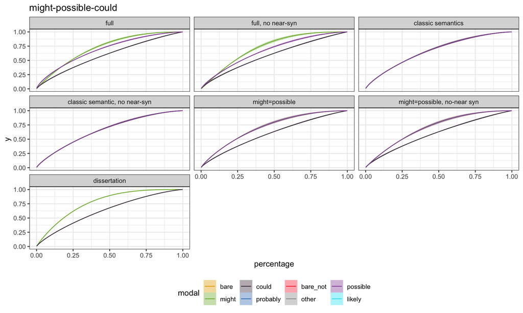

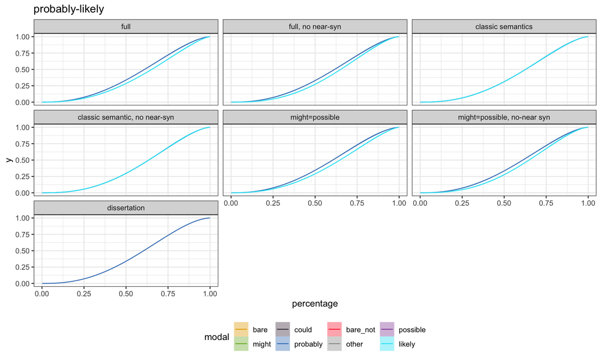

### Comparison across models

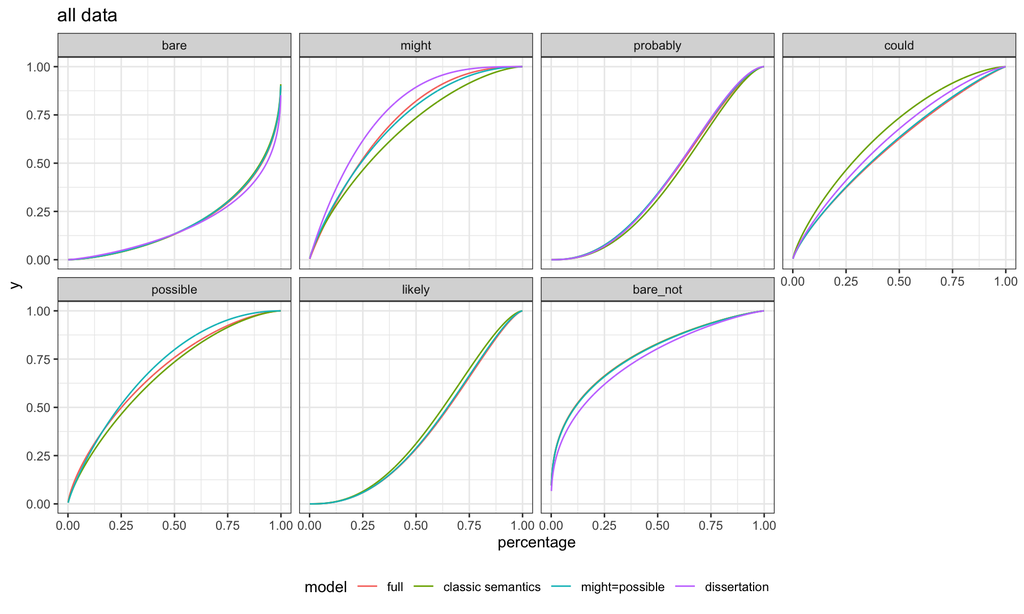

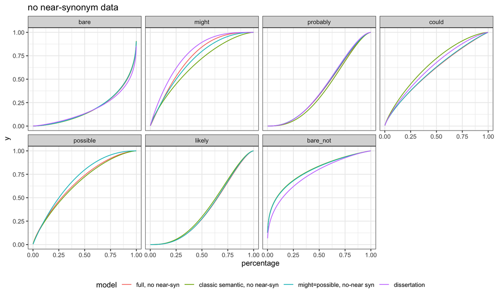